# 第7回 整理集計②：個票集計

経済データ入門

第7回

整理集計②：個票集計

平均を出しただけでは、赤字の 2 世帯は消える。個票まで降りれば、  
端にいる世帯を名指しで数えられる

経済データ入門

第7回 — Topic01

個票データと集計表

足し合わせる前の、1 行＝1 世帯の表

## 前回の振り返り

前回のポイント 第6回「整理集計①：地域指標」

Q: 47 行の県の表から、何を 1 行にしたか

- **47 行の表**：国や県が、県ごとに足し合わせた表
- **キー**：都道府県名で、ばらばらの表を 1 つにつないだ
- **フィルタ**：関東の 7 行に絞り、全国の約 4 割と読んだ

今日の相手は、足し合わせる前の 1 行＝1 世帯の表

## この回の道のりと「個票」シート

1

個票と集計表

2

名札を付ける

演習 7-1

年齢の 3 区分

3

条件で数える

演習 7-2

貯蓄率 10% 未満

4

ピボットで照合

演習 7-3

貯蓄率の低い年齢

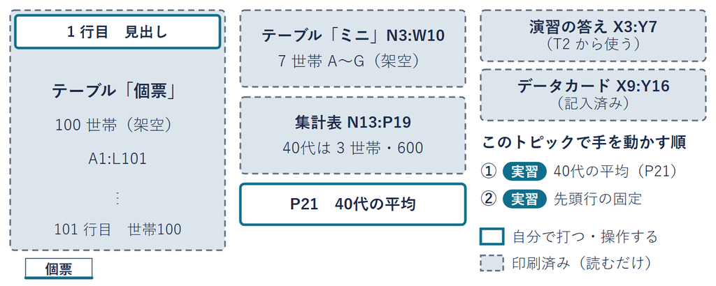

置き場は lec7-exercise.xlsx の「個票」シート。1 つのシートで回を通す

## 集計表で見る 40代の貯蓄

前の回までは、県ごとに足し合わせた表を読んできた  
40代の家の平均貯蓄も、集計表なら 1 行で分かる  
でも、自分の家と比べたいとき、この 1 行で足りるか

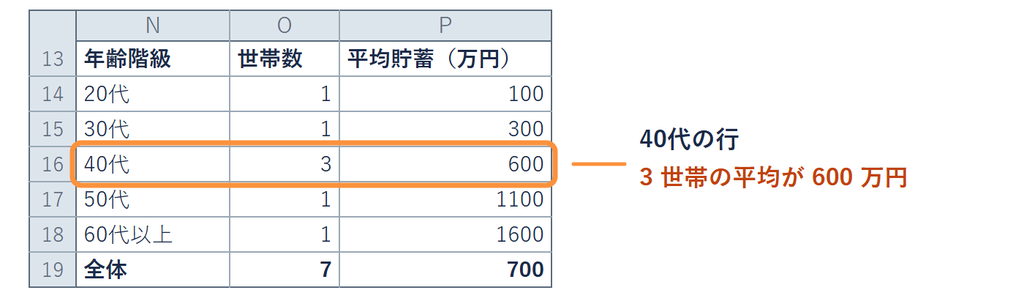

**サンプルデータ**：架空の 7 世帯の集計表  
（lec7-exercise.xlsx「個票」の N13:P19）

## たしかめ 40代の 3 世帯

集計表では、40代は 3 世帯で、平均貯蓄は 600 万円  
この 3 世帯は、どれも 600 万円くらい貯めているか

**1 そう言える**

**2 この表からは分からない**

1 つ決めてから先へ。答えは、このトピックの中で出す

## 個票で見る 40代の 3 世帯

[figure not shown]

**サンプルデータ**：架空の 7 世帯  
（lec7-exercise.xlsx「個票」の N3:W10）

## 個票データと集計表

用語

**個票データ**：足し合わせる前の、1 行＝1 世帯の表

**集計表**：個票を、区分ごとに足し合わせた表

- **要点**：足し合わせると、1 世帯ずつの姿は消える
- **今回は**：40代の平均 600 万円の裏に、600・300・900 の 3 世帯
- **もう 1 つ**：平均にすると、D の赤字は目立たなくなる

最初の問いの答えは 2 番。1 世帯ずつの姿は、個票にしか残らない

## カテゴリー変数

用語

**カテゴリー変数**：分類の名札として使う列。量ではない

- **今回は**：ミニの性別コード。1＝男・2＝女
- **2 は 1 の 2 倍ではない**：番号は、分類に振った名札
- **平均しても**：1 と 2 を平均すると 1.5。1.5 は何も表さない
- **量の列**：年齢・月収・貯蓄は、足したり平均したりできる

## 40代の平均貯蓄の式

1. **選ぶ**：名前ボックスに  
   P21 と打つ  
   （N21 に「40代の平均」と  
   印刷済み）
2. **打つ**：`=AVERAGE(S6:S8)` で Enter  
   S6〜S8 は C・D・E の貯蓄
3. **見る**：P21 が 600  
   集計表の 40代（P16）と同じ

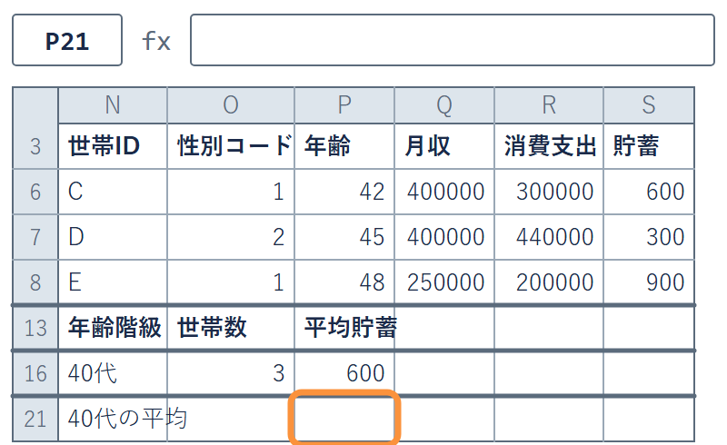

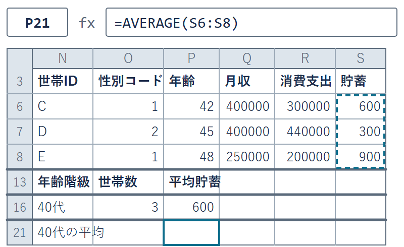

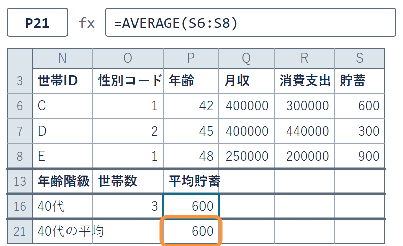

✋ 動画を止めて STEP 1〜3 を進め、P21 が 600 なら再生に戻る

## 100 世帯の個票

今度は、100 世帯の個票で、同じ 1 行＝1 世帯を見る

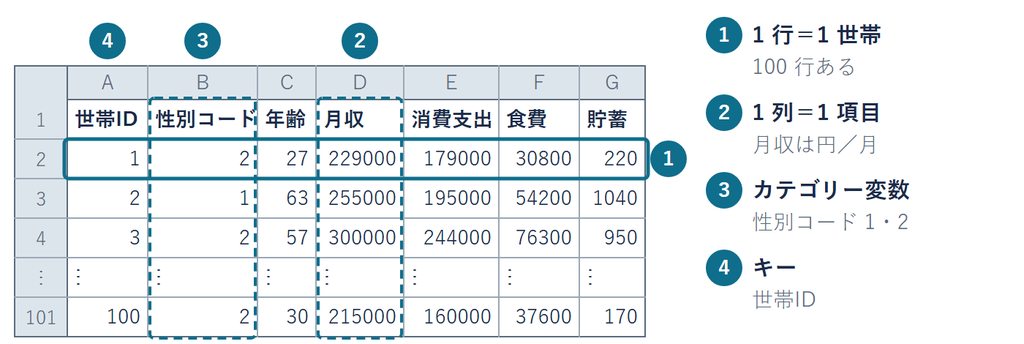

月収・消費支出・食費は円／月、貯蓄は万円の残高

**サンプルデータ**：架空の 100 世帯（lec7-exercise.xlsx「個票」の A1:L101）

H〜L 列の見出しは、あとのトピックで使う

## たしかめ 本物の個票

本物の全国家計構造調査にも、1 世帯ずつの表（個票）がある  
この個票は、e-Stat からダウンロードできるか

**1 できる**

**2 できない**

1 つ決めてから先へ。答えは、次のページで出す

## 個票データの公開

答え

答えは 2 番。個票は公開されない。  
ウェブで見られるのは集計表だけ

- **なぜ**：誰がいくら稼ぎ、いくら貯めたかが 1 世帯ずつ書いてある
- **困ること**：その世帯が誰か、特定されうる
- **例外**：研究などの決まった目的で申請する制度はある
- **この授業では**：項目の並びをまねた架空の 100 世帯で練習する

数字は架空でも、集計の手つきは本物と同じ

## 全国家計構造調査のデータカード

| 欄 | 全国家計構造調査のカード（記入済み） |
| --- | --- |
| 統計名・表番号 | 全国家計構造調査（2019年調査から。旧称は全国消費実態調査） |
| 作成機関 | 総務省統計局 |
| 調査の種類 | **標本調査**・世帯が対象・**5 年ごと** （2024年が 14 回目・約 90,000 世帯） |
| 単位・基準 | 円／月（家計収支）・万円（貯蓄現在高）・名目 |
| 定義の落とし穴 | 個票は公開されない・家計調査とは対象と規模が違い 数字は一致しない・「最新」も数年前の姿 |
| 入手先・取得日 | e-Stat（政府統計コード 00200564）・2026年9月22日 |
| 出典 4 点セット | 総務省統計局「全国家計構造調査（2024年）」 2026年9月22日取得 |

欄は前の回と同じ 7 つ。ブックの X9〜Y16 に記入済み

## 先頭行の固定

1. **飛ぶ**：A2 を選び `Ctrl` + `↓`  
   （Mac では `⌘` + `↓`）  
   A101 に着き、  
   見出しが画面から消える
2. **固定**：名前ボックスで A1 に戻り  
   「表示」タブの  
   「ウィンドウ枠の固定」から  
   「先頭行の固定」
3. **見る**：もう一度 A2  
   から `Ctrl` + `↓`  
   A101 が 100。  
   見出しは 1 行目に残る

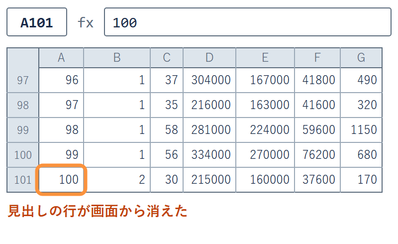

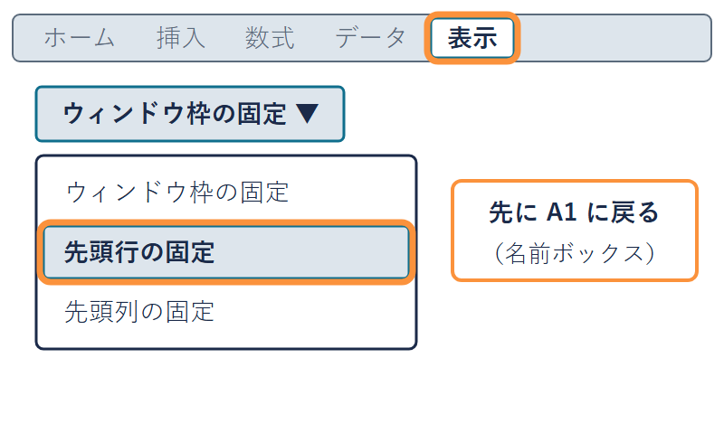

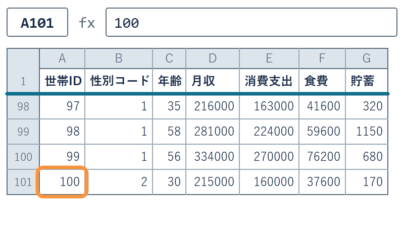

✋ 動画を止めて STEP 1〜3 を進め、見出しが残れば再生に戻る

## まとめ

- **個票データ**：足し合わせる前の、1 行＝1 世帯の表
- **集計表**：個票を区分ごとに足した表。1 世帯ずつの姿は消える
- **カテゴリー変数**：性別コードの 1 と 2 は名札で、量ではない
- **100 世帯**：架空のサンプル。本物の個票は公開されない

100 行から赤字の世帯を目で拾うのは難しい。  
行ごとに名札を付けられないか  
これを次のトピックで見る

経済データ入門

第7回 — Topic02

条件分岐 — IF と IFS

条件を書いて 2 つ以上に分ける

## この回の道のりと「個票」シート

1

個票と集計表

2

名札を付ける

演習 7-1

年齢の 3 区分

3

条件で数える

演習 7-2

貯蓄率 10% 未満

4

ピボットで照合

演習 7-3

貯蓄率の低い年齢

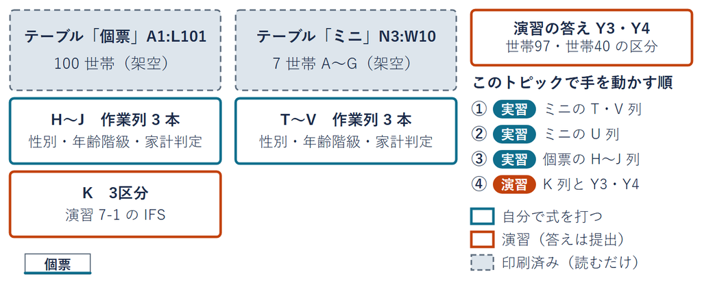

lec7-exercise.xlsx「個票」の T〜V 列と H〜K 列に式を打つ

## 目で探す赤字の世帯

前のトピックでは、ミニの D が赤字だと目で見つけた  
100 行で月収と消費支出を見比べると、見落とす  
行ごとに、黒字か赤字かの名札を付けられないか

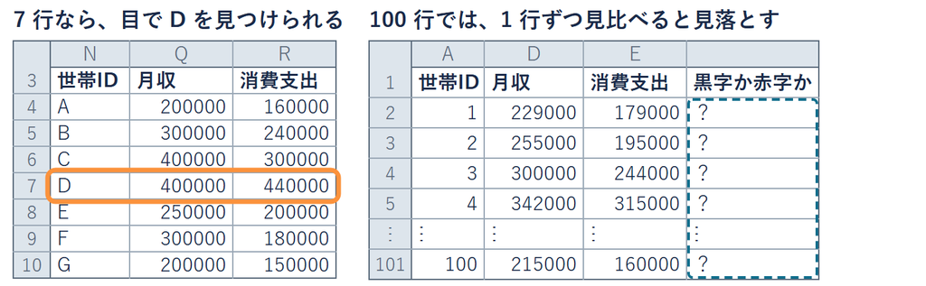

**サンプルデータ**：lec7-exercise.xlsx「個票」のミニ  
（N3:W10）と個票（A1:L101）

## 論理式と比較演算子

用語

**論理式**：答えが TRUE か FALSE になる式

**比較演算子**：2 つの値を比べる記号

- **TRUE と FALSE**：TRUE は成り立つ、FALSE は成り立たない
- **比較演算子は 6 つ**：`=`・`<>`・`>`・`<`・`>=`・`<=`
- **読み方**：`<` は未満（等しいときは含まない）、`>=` は以上、`<=` は以下
- **`[@月収]`**：この行の月収。前に出てきたテーブルの書き方

今回は `[@月収]>=[@消費支出]`  
A は 200000>=160000 で **TRUE**、D は 400000>=440000 で **FALSE**

## IF の式

公式

`=IF(論理式, 真の場合, 偽の場合)`

- **真の場合**：論理式が TRUE のときに返す値
- **偽の場合**：論理式が FALSE のときに返す値
- **できること**：条件を 1 回書けば、どの行にも同じ判定が付く

今回は `=IF([@月収]>=[@消費支出],"黒字","赤字")`

月収が消費支出以上なら黒字、そうでなければ赤字

## 7 世帯の家計判定

[figure not shown]

**サンプルデータ**：ミニの 7 世帯  
（lec7-exercise.xlsx「個票」の N3:W10）

式は 1 本。D だけが FALSE で赤字

## 性別コードの IF

今回はもう 1 本 `=IF([@性別コード]=1,"男","女")`

- **論理式**：`[@性別コード]=1`。1 なら TRUE で「男」
- **そうでなければ**：FALSE で「女」。コードは 1 と 2 だけなので、2 は女
- **1＝男・2＝女**：このブックの決め（サンプルデータの約束）
- **文字の値**：`"` でくくる。くくらないとエラー（#NAME?）

1 と 2 は名札の番号。式が、言葉の名札に直す

## 作業列

用語

**作業列**：元の列の右に足す、名札を入れる列

- **目で塗れば？**：7 行ならできる。100 行では見落とす
- **式なら**：月収を直すと、名札も付き直る
- **元の列は**：そのまま。月収も消費支出も書き換えない

名札は、式に付けさせる

## ミニの性別と家計判定の式

1. **打つ**：名前ボックスで T4 へ移り  
   p.23 の性別の IF で Enter
2. **打つ**：V4 に論理式だけ  
   `=[@月収]>=[@消費支出]`  
   V7（D の行）だけ FALSE
3. **くるむ**：V4 を IF の式に打ち直す  
   V7 が赤字（V10 まで入れ替わる）

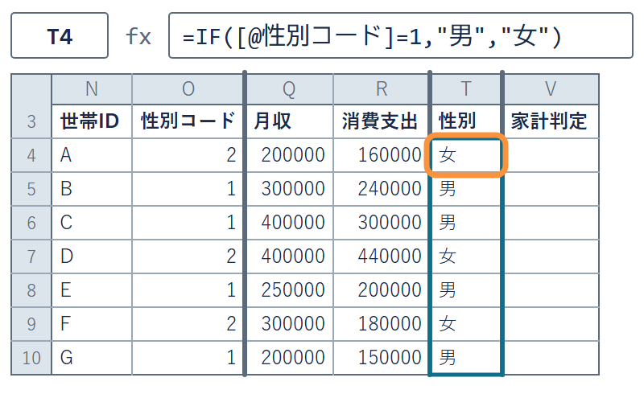

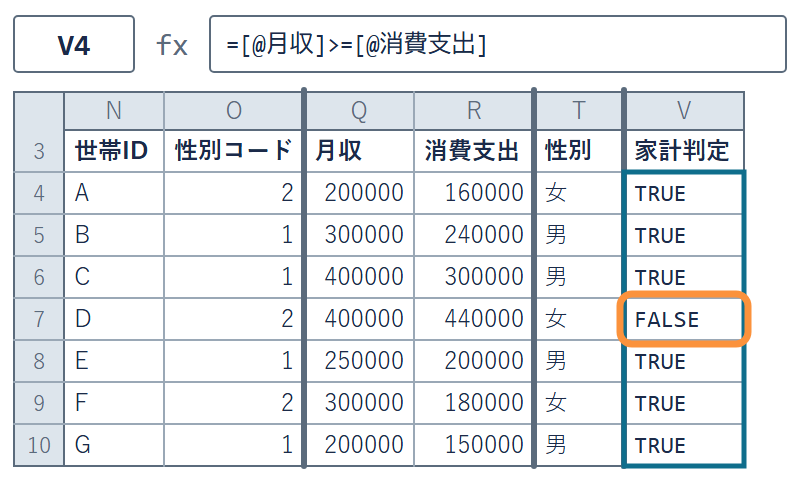

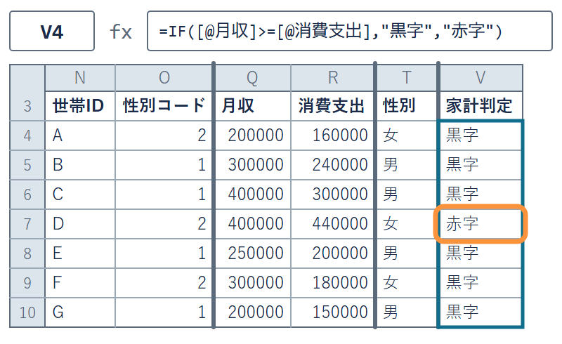

✋ 動画を止めて STEP 1〜3 を進め、V7 が赤字なら再生に戻る

## 5 つに分けたいとき

IF で 2 つに分けられた。年齢は、集計表と同じ 5 つに分けたい

`=IF([@年齢]<30,"20代"``,``IF([@年齢]<40,"30代"``,`  
`IF([@年齢]<50,"40代"``,``IF([@年齢]<60,"50代"``,``"60代以上"``)``)``)``)`

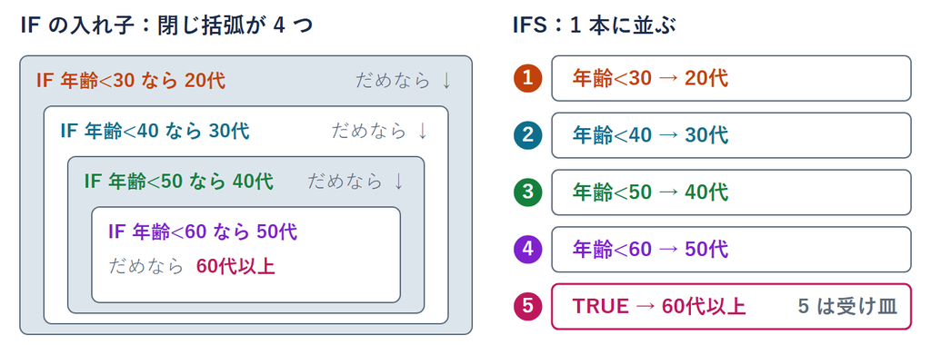

## IFS の式

公式

`=IFS(条件1, 値1, 条件2, 値2, …, TRUE, 受け皿の値)`

- **読み方**：条件1 が成り立てば値1 を返す。だめなら条件2 へ
- **受け皿**：最後の TRUE はいつでも成り立つ。残りの行を受ける
- **使える版**：Excel 2019 以降と 365。古い版は IF を重ねれば同じ答え

今回は

`=IFS(``[@年齢]<30,"20代"``,``[@年齢]<40,"30代"``,`  
`[@年齢]<50,"40代"``,``[@年齢]<60,"50代"``,`  
`TRUE,"60代以上"``)`

## たしかめ A は 27 歳

A は 27 歳。`<30`・`<40`・`<50`・`<60` の 4 つとも成り立つ  
年齢の IFS は、どれを返すか

**1 20代**

**2 50代**

**3 エラー**

1 つ決めてから先へ。答えは、次のページで出す

## 左から順に通る関門

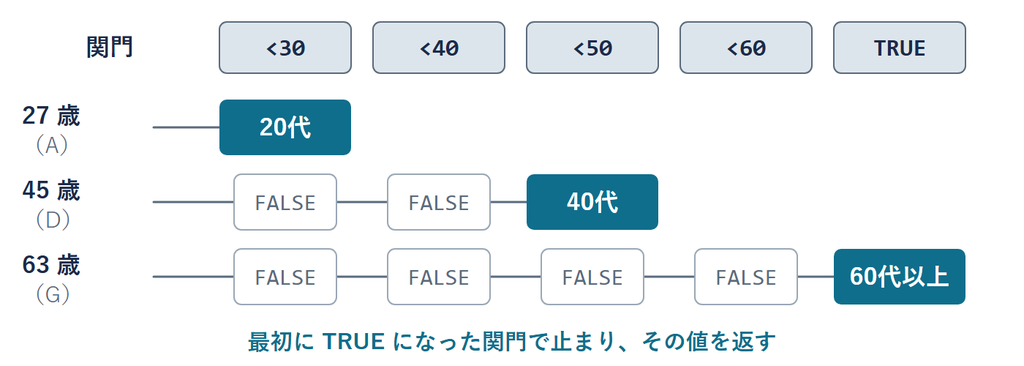

答えは 1 番。A は最初の関門で止まり、20代

## IFS の決まり

決まり

IFS は**上から順に**判定し、**最初に成り立った**条件の値を返す

- **`<40` だけで 30代**：`<30` を通らなかった行だけが来る
- **受け皿**：最後の TRUE は常に成り立つ。残りを全部受ける（G）
- **書き忘れると**：どの条件も成り立たない行は #N/A のエラー
- **並べ方**：境界の小さい順に書く

## 失敗例 広い条件が先頭の IFS

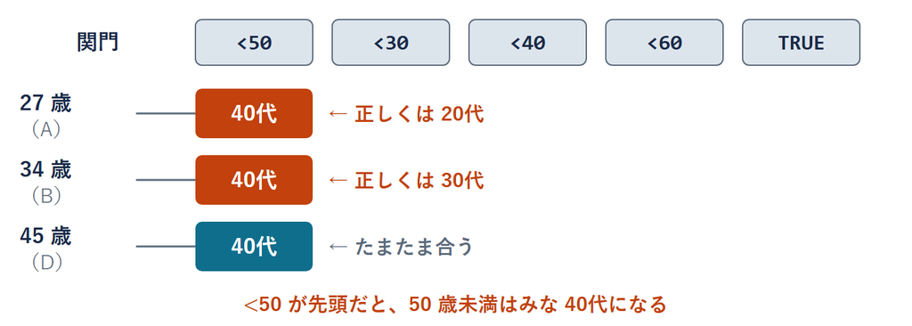

40代を先に書きたくなるが、`<50` は 27 歳も通してしまう

## ミニの年齢階級の式

1. **打つ**：U4 に年齢の IFS で Enter  
   （式は p.27）  
   `<` は `Shift` ＋ カンマ  
   （Mac も同じ）
2. **見る**：U10 まで年齢階級が入る  
   40代は C・D・E の 3 つ
3. **見る**：U4 が 20代  
   U10 が 60代以上（受け皿）

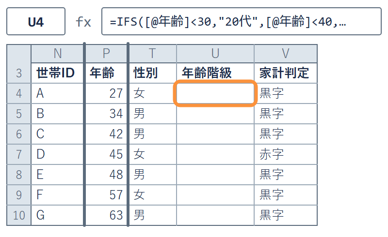

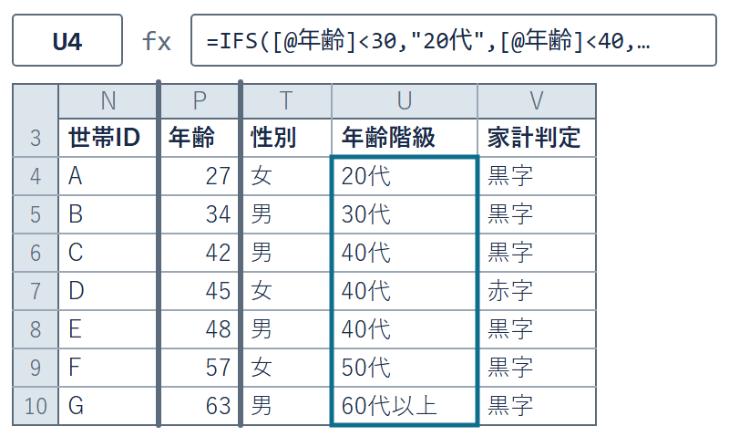

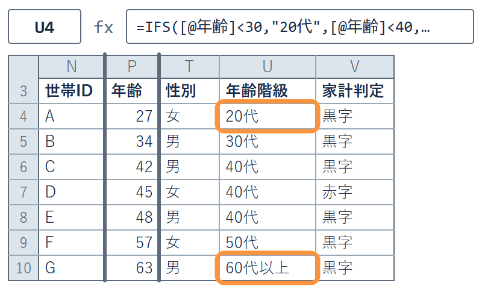

✋ 動画を止めて STEP 1〜3 を進め、U10 が 60代以上なら再生に戻る

## 100 世帯に同じ 3 本

今度は 100 世帯の個票で、同じ 3 本の式を打つ  
式の字はミニと同じ。`[@年齢]` はこの行の年齢

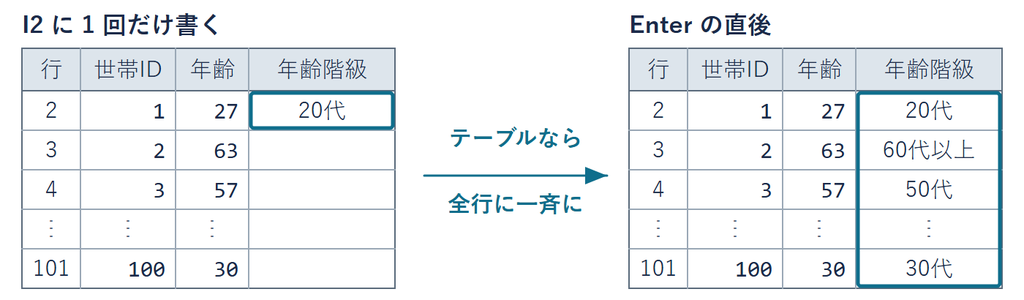

**サンプルデータ**：架空の 100 世帯（lec7-exercise.xlsx「個票」の A1:L101）

前提：性別コードは 1 と 2 だけ・年齢 25〜73 歳・空欄なし  
月収と消費支出が同じなら、`>=` なので黒字

## 個票の作業列 3 本

1. **打つ**：H2 に性別の式で Enter  
   式はミニと同じ（H1 に「性別」）
2. **打つ**：I2 に年齢の IFS  
   J2 に家計判定の IF  
   （式はミニと同じ）
3. **見る**：2 行目（世帯1）は  
   女・20代・黒字。5 行目（世帯4）は  
   男・40代・黒字

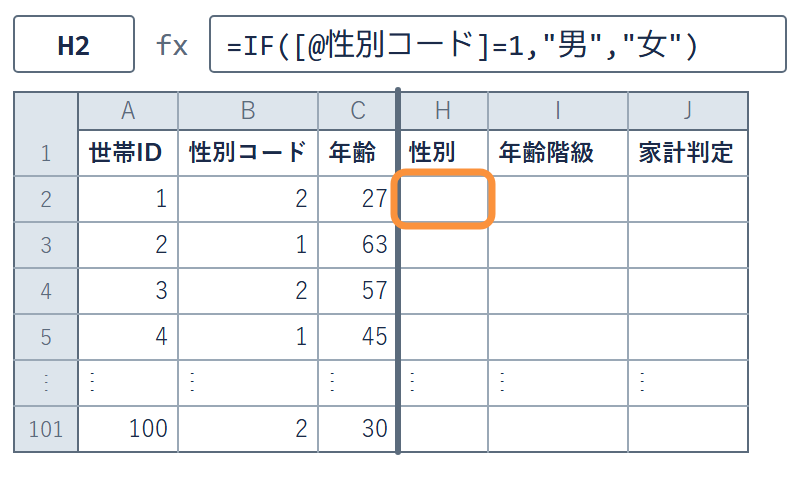

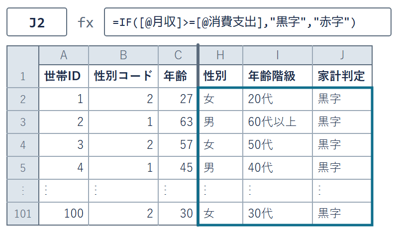

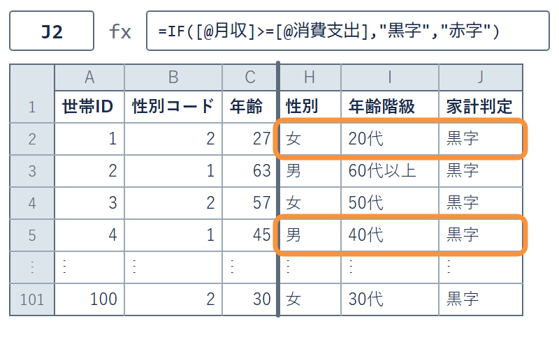

✋ 動画を止めて STEP 1〜3 を進め、5 行目が男・40代・黒字なら再生に戻る

## 演習 7-1 年齢の 3 区分

演習 7-1

境界ちょうどの 35 歳と 55 歳は、どの区分に入るか

1. **作る場所**：K 列「3区分」の K2 に IFS。名札は 35歳未満・35〜54歳・55歳以上
2. **変える所**：I 列の IFS を手本に、条件を 2 つに減らす  
   境界は 35 と 55。余った 2 組は消す
3. **考える問い**：世帯97（98 行目）は 35 歳。世帯40（41 行目）は 55 歳  
   どちらの区分も、式を打つ前に予想する
4. **書く**：K98 と K41 に出た区分を、Y3 と Y4 に打つ

✋ 動画を止めて 5 分。Y3・Y4 に打ったら再生に戻る

## 演習 7-1 の答えの例

`=IFS([@年齢]<35,"35歳未満",`  
`[@年齢]<55,"35〜54歳",TRUE,"55歳以上")`

| 世帯 | 年齢 | 関門の通り方 | 区分 |
| --- | --- | --- | --- |
| 世帯97（98 行目） | 35 | `<35` は FALSE、`<55` で止まる | **35〜54歳** |
| 世帯40（41 行目） | 55 | `<55` も FALSE、受け皿へ | **55歳以上** |

- **Y3・Y4**：35〜54歳 と 55歳以上
- **境界ちょうど**：`<35` は 35 を含まない。だから 35 歳は次の関門へ

## まとめ

- **論理式**：TRUE か FALSE になる式。比べる記号は 6 つ
- **IF**：条件が成り立てば 1 つ目の値、だめなら 2 つ目の値
- **IFS**：上から順に判定し、  
  最初に成り立った所の値。最後の TRUE が受け皿
- **作業列**：元の列の右に足す名札の列。1 つ目に打てば列全体に入る

条件を 1 回書けば、100 行に名札が付いた。  
名札の付いた行を、どう数えるか  
これを次のトピックで見る

経済データ入門

第7回 — Topic03

条件つき集計 —  
COUNTIF・SUMIF・AVERAGEIF

絞り込みと集計を、式 1 本にする

## この回の道のりと「個票」シート

1

個票と集計表

2

名札を付ける

演習 7-1

年齢の 3 区分

3

条件で数える

演習 7-2

貯蓄率 10% 未満

4

ピボットで照合

演習 7-3

貯蓄率の低い年齢

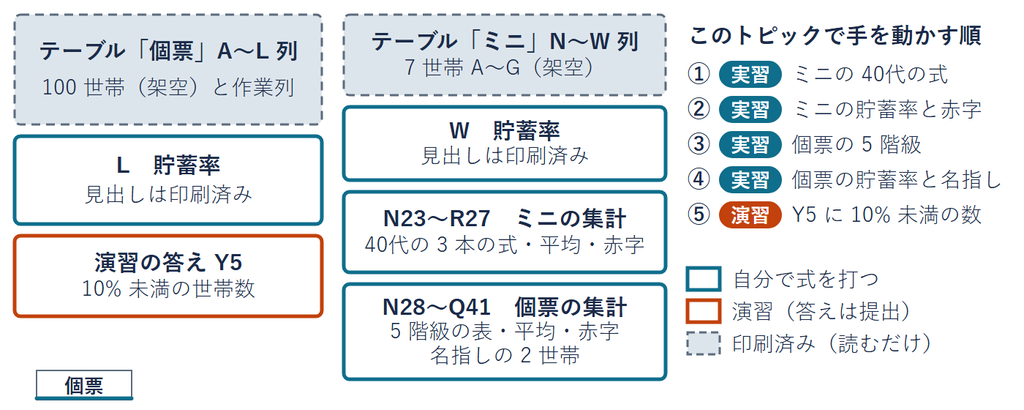

lec7-exercise.xlsx「個票」の W 列・L 列と、N23 から下の表に式を打つ

## 目で拾う 40代の行

最初のトピックでは、ミニの 40代 3 行を目で拾って平均した  
100 行では、40代がばらばらの行にいて、拾い落とす  
名札を条件にして、数える・足す・平均するを式 1 本にできないか

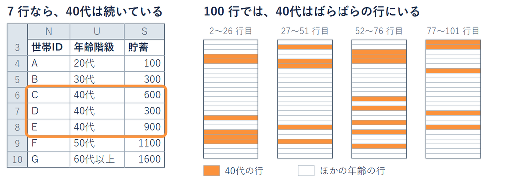

**サンプルデータ**：lec7-exercise.xlsx「個票」のミニ  
（N3:W10）と個票（A1:L101）

## ミニの 40代の 3 つの集計

[figure not shown]

**サンプルデータ**：ミニの 7 世帯  
（lec7-exercise.xlsx「個票」の N3:W10）

40代の行だけで、数える・足す・ならす

## 条件つき集計

用語

**条件つき集計**：条件に合う行だけを、数える・足す・平均する

- **できること**：「絞り込み」と「集計」を、式 1 本でする
- **今回は**：条件は「年齢階級が 40代」。  
  答えは 3 世帯・1,800 万円・600 万円
- **フィルタとの違い**：フィルタは表示を絞るだけ。  
  式なら答えがセルに残る

答えをセルに残すなら、式で書く

## COUNTIF・SUMIF・AVERAGEIF の式

公式

`=COUNTIF(条件範囲, 条件)`：数える

`=SUMIF(条件範囲, 条件, 合計範囲)`：足す

`=AVERAGEIF(条件範囲, 条件, 平均範囲)`：平均する

- **条件範囲**：条件を確かめる列。今回は `ミニ[年齢階級]`
- **`ミニ[年齢階級]`**：ミニの年齢階級の列全体
- **合計範囲・平均範囲**：見る列と足す列が違うので、範囲を 2 つ書く
- **条件**：N25（「40代」）を指す。下へ写せば使い回せる

## 3 つの式の関係

| セル | 今回の式 | 答え |
| --- | --- | --- |
| O25 | `=COUNTIF(ミニ[年齢階級],N25)` | 3 |
| P25 | `=SUMIF(ミニ[年齢階級],N25,ミニ[貯蓄])` | 1,800 |
| Q25 | `=AVERAGEIF(ミニ[年齢階級],N25,ミニ[貯蓄])` | 600 |

関係

AVERAGEIF ＝ SUMIF ÷ COUNTIF。今回は 1,800 ÷ 3 ＝ 600

最初のトピックで目で拾って出した 600 と同じ

## ミニの 40代の集計の式

1. **打つ**：名前ボックスで O25 へ移り  
   p.44 の COUNTIF の式
2. **打つ**：P25 に SUMIF、  
   Q25 に AVERAGEIF  
   3・1,800・600 が並ぶ
3. **確かめる**：R25 に `=P25/O25`  
   R25 も 600（Q25 と同じ）

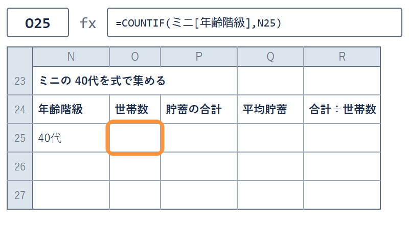

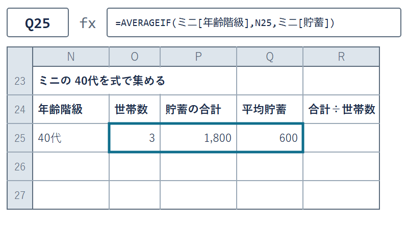

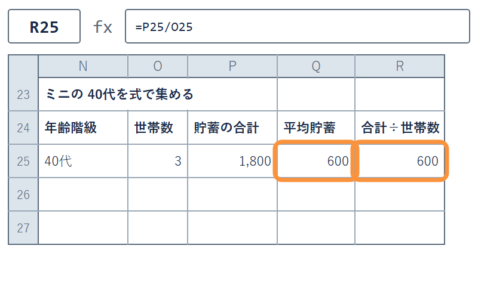

✋ 動画を止めて STEP 1〜3 を進め、R25 が 600 なら再生に戻る

## 貯蓄率

貯蓄（残高）の平均は出せた。残高は長く働いた家ほど多い  
今月お金が残ったかを、月収の違う家どうしで比べるには

定義

**貯蓄率**：（月収 − 消費支出）÷ 月収 × 100（%）

- **意味**：稼いだお金のうち、使わずに残せた割合。マイナスなら赤字
- **なぜ月収で割る**：月収 20 万円の家と 40 万円の家は、  
  残った額のままでは比べられない
- **今回は**：A は（200,000 − 160,000）÷ 200,000 × 100 ＝ 20
- **Excel では**：`=([@月収]-[@消費支出])/[@月収]*100`

## ミニの貯蓄率の式

1. **打つ**：W4 に貯蓄率の式で Enter  
   （式は p.46・W3 に印刷済み）
2. **見る**：W10 まで入る  
   表示は小数 1 桁にしてある
3. **打つ**：P26 に次の式  
   `=AVERAGE(ミニ[貯蓄率])`

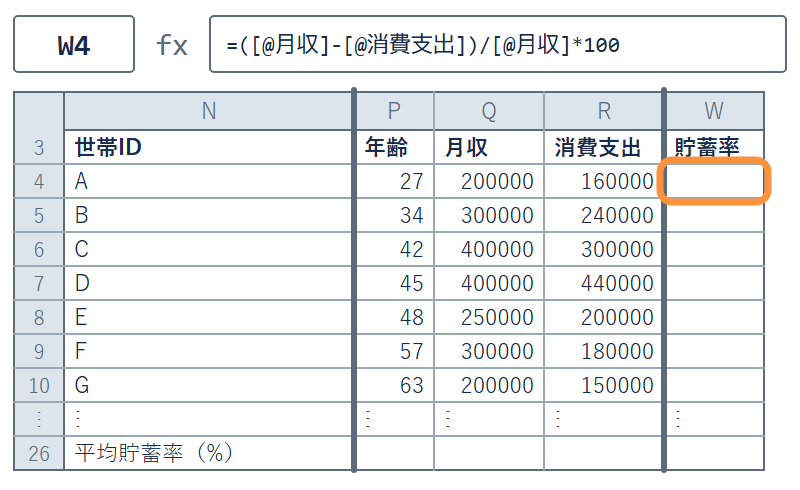

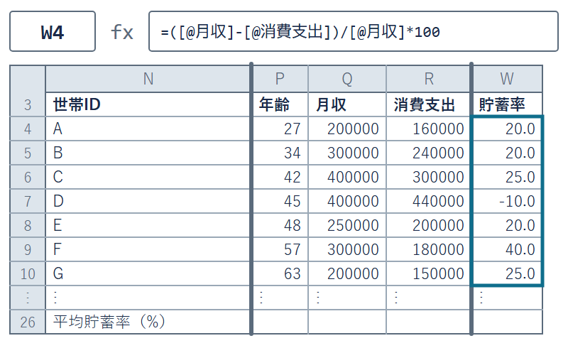

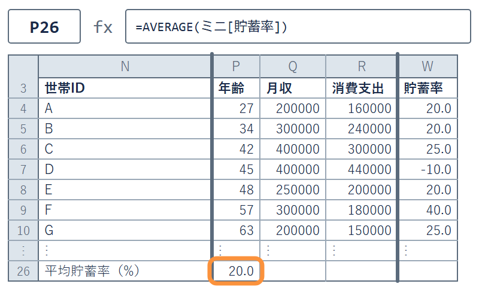

✋ 動画を止めて STEP 1〜3 を進め、P26 が 20.0 なら再生に戻る